# Weekly Energy Charts

June 10, 2022

[Sign up here to get on our email list](https://docs.google.com/forms/d/e/1FAIpQLSckqeGjUvIlhveVyjmkXe913tzQRLANqPNQzEZTUQD2hQxH8g/viewform?usp=pp_url)

# Featured Stories

## Net Zero Oil Sands?

#### [Marc Vermette](https://ca.linkedin.com/in/marc-vermette)

The challenge is significant, however, as oil sands are among the most emissions-intensive sources of oil in the world.

[Emissions associated with the extraction and processing for a selection of crudes produced in North America](https://www.pembina.org/blog/real-ghg-trend-oilsands)

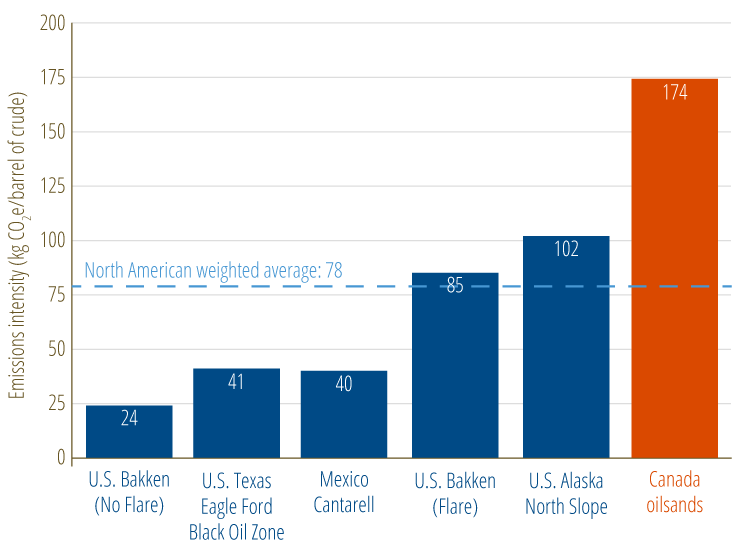

Graph by [Pembina Institute](https://www.pembina.org/about/about-pembina)

In the first phase of their Net Zero pathway, the oil sands producers expect to eliminate 22 megatonnes of annual emissions by 2030, with 10 megatonnes coming from CCUS projects.

“Research is going to be required for us if we’re going to win the energy transition — and we’re going to win it,” (James Dunn, Imperial Oil’s director of sustainable technology integration)

A majority of the technology needed to lower oil sands emissions is understood, but the key will be making the finances work.

“[Ultimately, there] will be a preference for stable, secure hydrocarbons from countries like Canada…” (Jackie Forrest, executive director of ARC Energy Research Institute)

[Original Article](https://calgaryherald.com/opinion/columnists/varcoe-net-zero-oilsands-lng-pivotal-for-the-future-of-canadas-energy-sector)

## Forecasted energy production in Alberta

#### Erica Beattie

The Edmonton Journal’s recent article reports that energy output in Alberta is on the rise, with production to top $163B in 2022.

The Alberta Energy Regular released their [annual energy outlook for 2022](https://static.aer.ca/prd/documents/sts/ST98/2022/ST982022_ExecutiveSummary.pdf) just last week. It forecasts that Alberta will see an increase in the production of most energy sources through 2031. Domestic hydrogen production in particular is expected to increase by over a million tonnes in the next decade with [several projects](https://www.alberta.ca/hydrogen-roadmap.aspx) announced this past year in Alberta.

Due to increases in global energy demand and strong prices, AER also forecasts higher capital expenditures by the oil and gas industry.

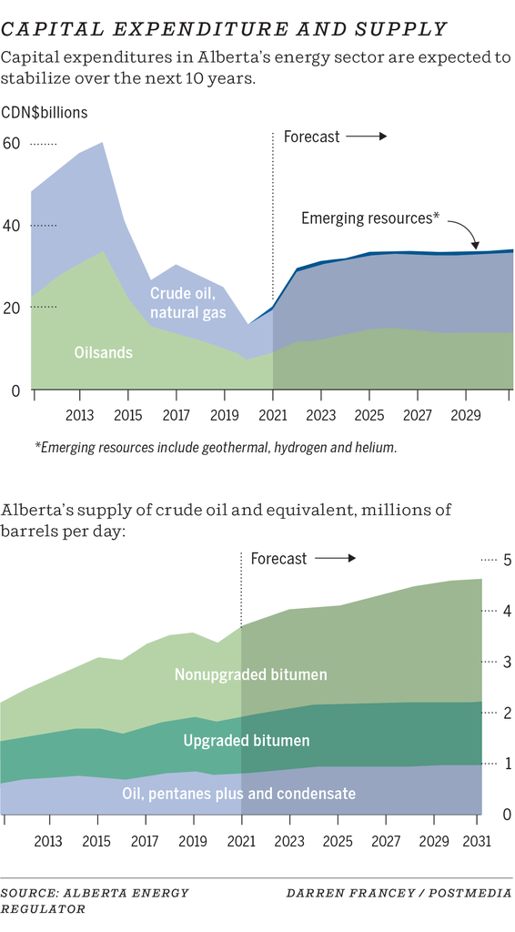

Energy Sector Capital Expenditure and Supply

## Energy Week

#### Erica Beattie

June 6th-10th is officially [Energy Week in Alberta](https://open.alberta.ca/dataset/energy-week-declaration/resource/7efa34d4-e19c-4f3e-b9c1-2cb2efaaeed6). The government declared this week to recognize the importance of the energy sector to Alberta’s past, present, and future. We in Alberta are blessed with an abundance of energy resources and the province’s energy sector supports nearly a [quarter million jobs](https://thebusinesscouncil.ca/publication/the-importance-of-canadas-energy-sector/#:~:text=The%20energy%20sector%20here%20in,far%20surpasses%20the%20national%20average). So it seems only right that there be an entire week dedicated to energy in Alberta.

## India-Canada Climate Agreement

#### Debosree Mukherjee

On June 2nd, India and Canada signed a [Memorandum of Understanding](https://www.canada.ca/en/environment-climate-change/news/2022/06/canada-and-india-sign-memorandum-of-understanding-to-establish-stronger-cooperation-on-environmental-protection-and-climate-action.html) to increase cooperation on climate action and environmental protection. Both countries have agreed to collaborate in areas such as

- increasing renewable energy capacity,
- decarbonizing heavy industries,
- reducing plastic pollution,
- supporting the sound management of chemicals,
- ensuring sustainable consumption.

This new agreement gives Canada an opportunity to export its renewable energy technologies to India, the world’s third-largest emitter of GHGs. However, it leaves out the production and consumption of coal in India, a key environmental issue. [Coal produced about 40% of the world’s emissions in 2020](https://www.ctvnews.ca/climate-and-environment/climate-agreement-between-canada-india-discusses-renewable-energy-but-omits-coal-1.5930406), and India is the second largest producer and consumer of coal. Due to challenges regarding India’s growing population, energy demand, and poverty, the country continues to rely heavily on coal. Emissions from coal power in India has nearly tripled from 2000 to 2020. Coal is now responsible for almost half of India’s total carbon footprint. In contrast, emissions from coal power in Canada have decreased from 109 million tonnes in 2000 to 35 million tonnes in 2020. Canada’s Environment Minister has stated that although coal is not in the agreement, Canada will be looking to export renewable energy expertise to help India phase out its dependency on coal-fired electricity.

## New Energy Modelling Centre

#### [Yousaff Habib](https://www.linkedin.com/in/yousaff-habib-6684891a5/)

The University of Victoria, Polytechnique Montreal, and the University of Calgary received an investment of $5 million from Natural Resources Canada and have formed a national energy modelling hub. This will allow energy researchers to create models and simulations that can give them insights concerning energy sources 20 to 50 years in the future, and will influence policy decisions regarding the decarbonization of Canada. It’s hoped that the hub will become the central institution for all energy modelling in Canada moving forward. Each university will be playing a specific role, with the University of Victoria leading the technical aspects, Polytechnique Montreal acting as the central administrative hub, and the University of Calgary addressing the economic and political analysis. Despite the key roles of these institutions however, the project is open source, allowing their work to be available to anyone in the field. This marks another step towards reaching [net zero emissions by 2050](https://www.canada.ca/en/services/environment/weather/climatechange/climate-plan/net-zero-emissions-2050.html) in Canada, by informing policymakers about the environmental and economic impacts of their decisions before they happen.

[More details about the project can be found here](https://www.uvic.ca/news/topics/2022+energy-transition-madeleine-mcpherson+news)

# Oil

## Weekly Crude Prices

### Feature Crude

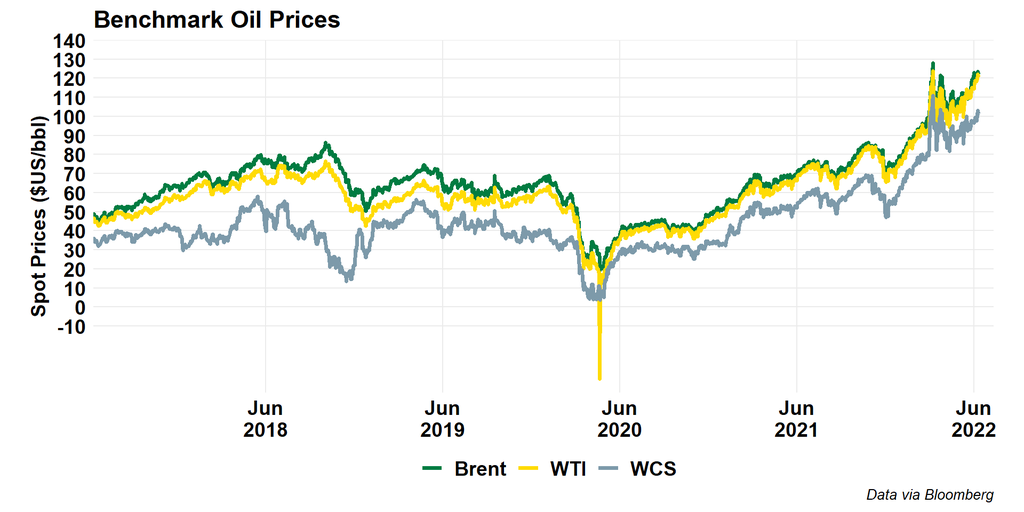

### Alberta Crude

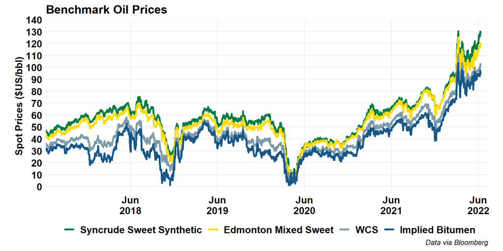

### US Crude

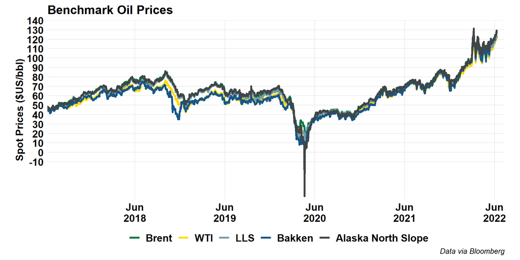

### Global Crude

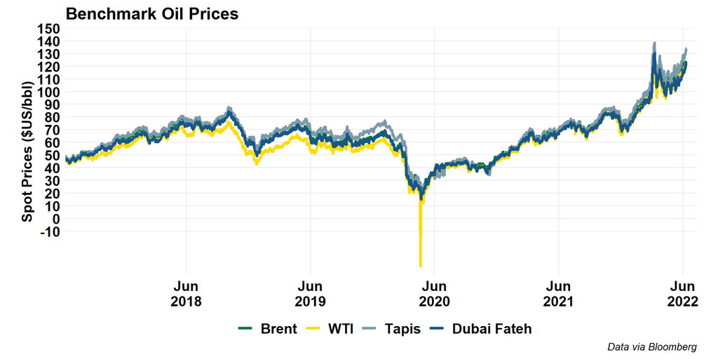

## Oil Price Differentials

### Brent-WTI

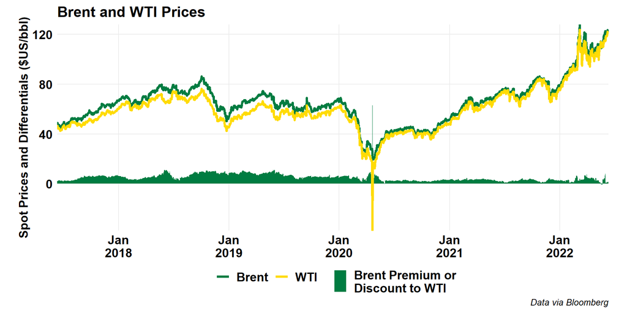

### WTI-WCS

[figure not shown]

### Maya-WCS

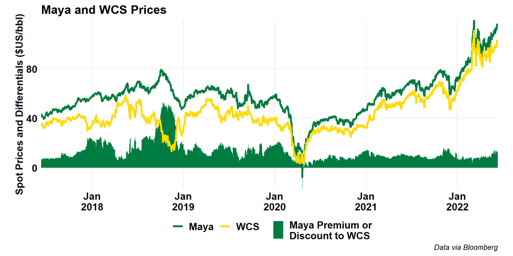

### WTI Cushing vs MEH

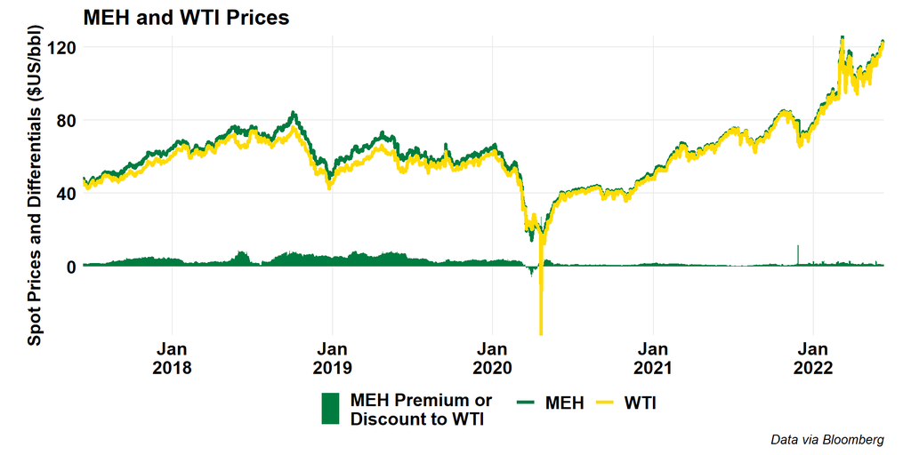

## Forward Curves

### WTI

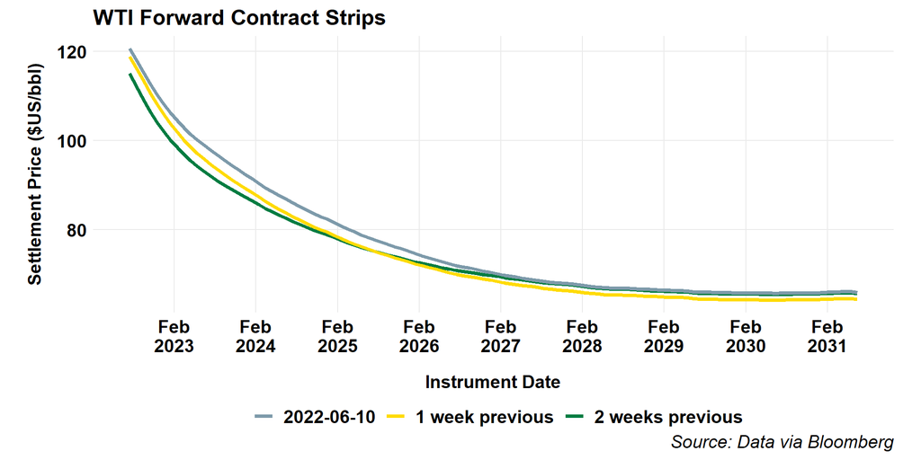

### Brent

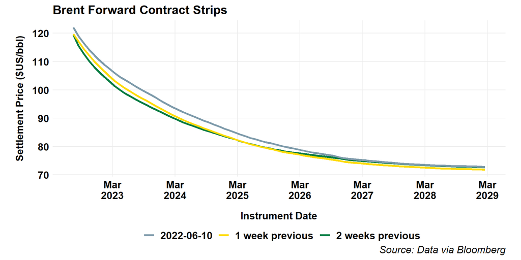

## Canadian Crude Supply and Disposition

### Production

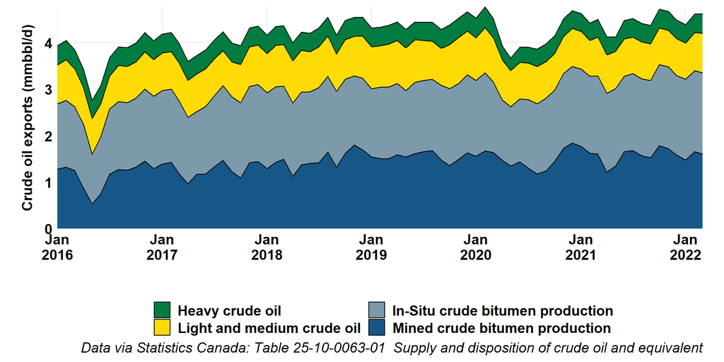

### Imports

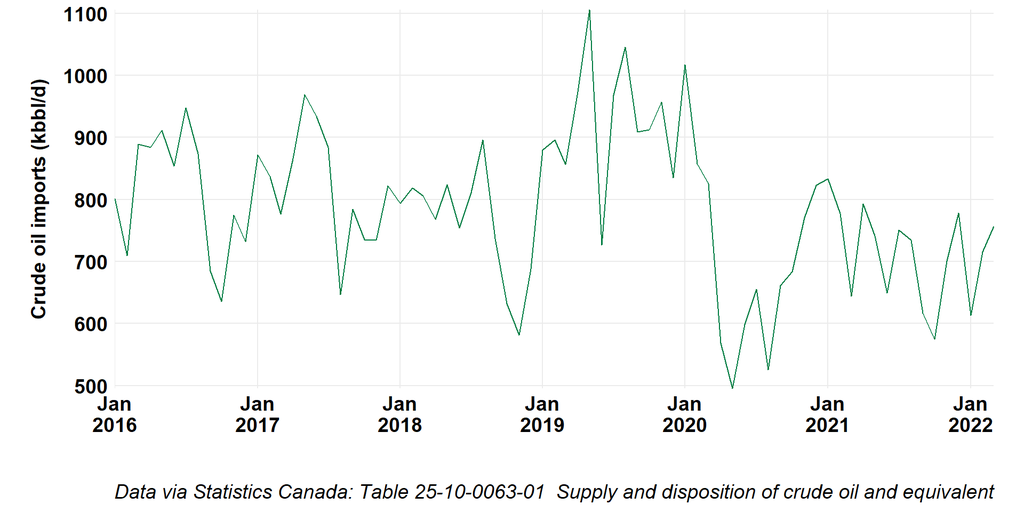

### Exports

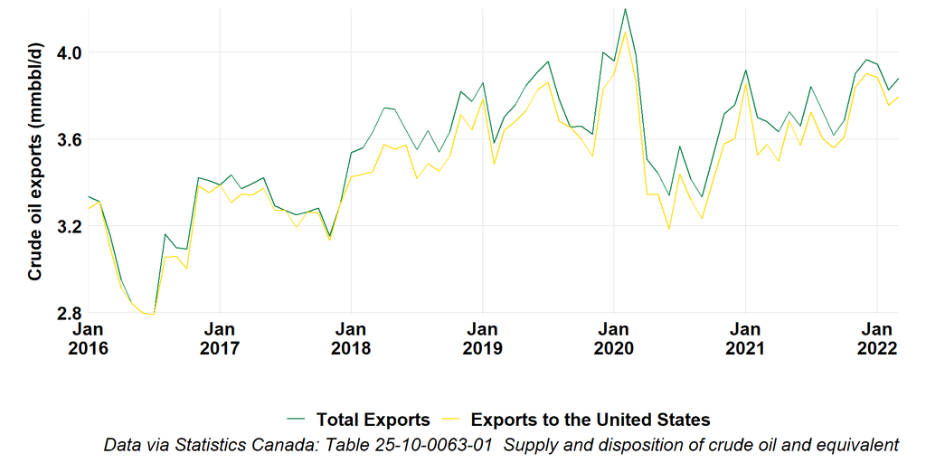

### Rail Exports

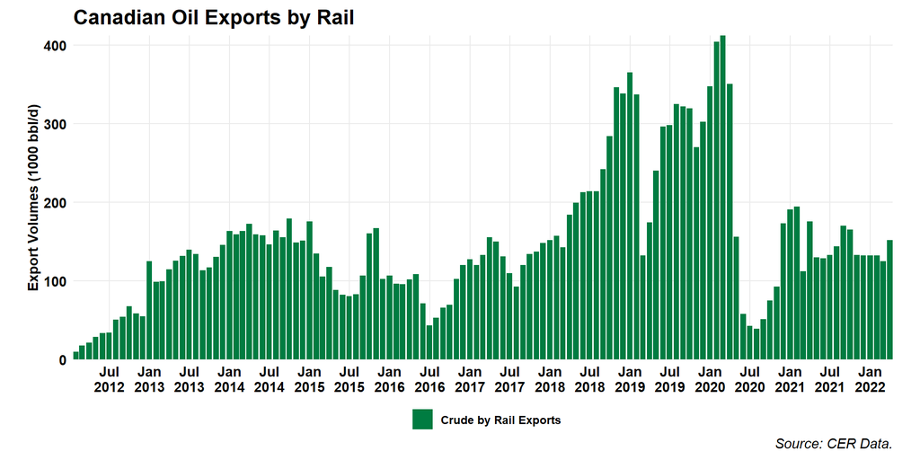

## US Oil

### Production

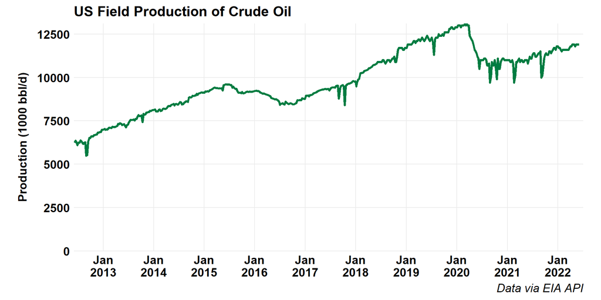

### LTO Production by Play

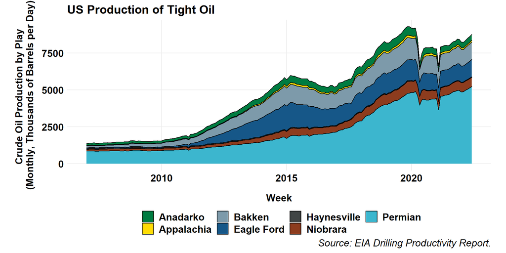

### Net Imports

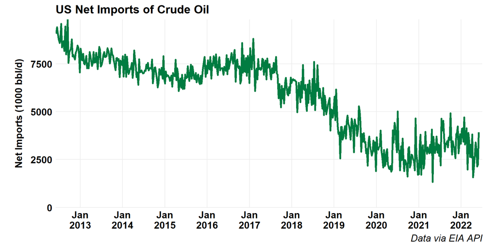

### Oil and Product Net Imports

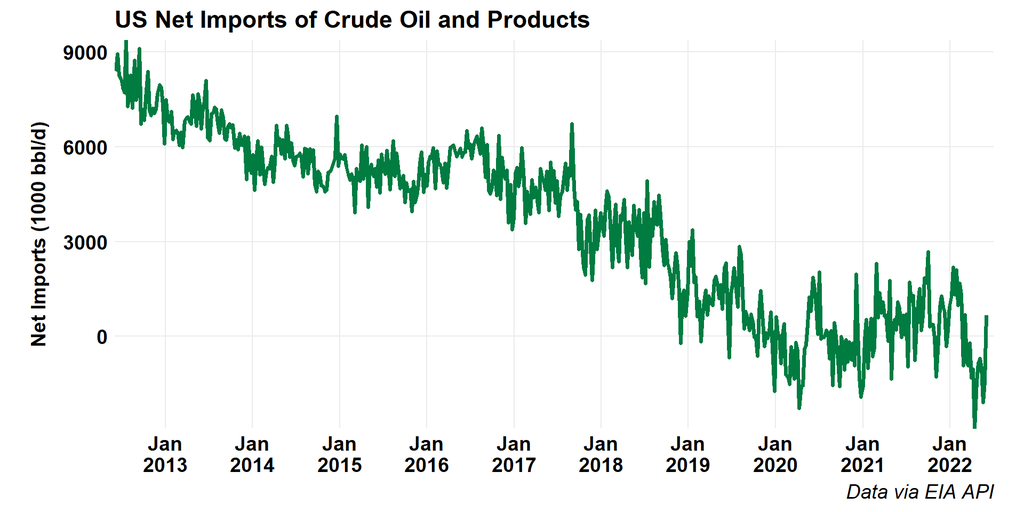

### Inventories

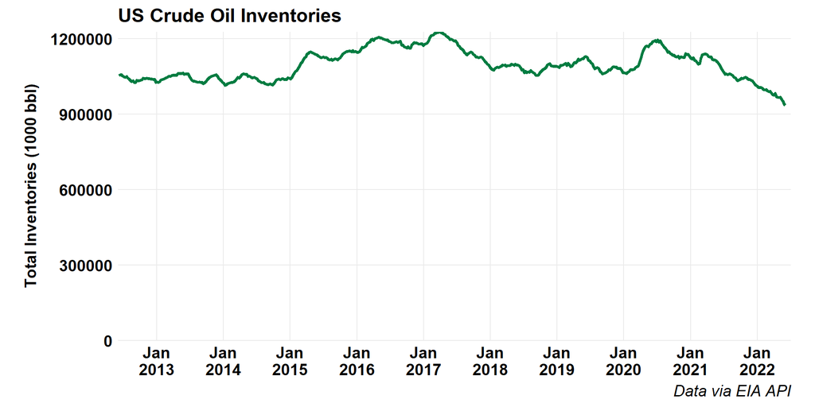

# Refined Products

## Canadian Gasoline Prices

### Map

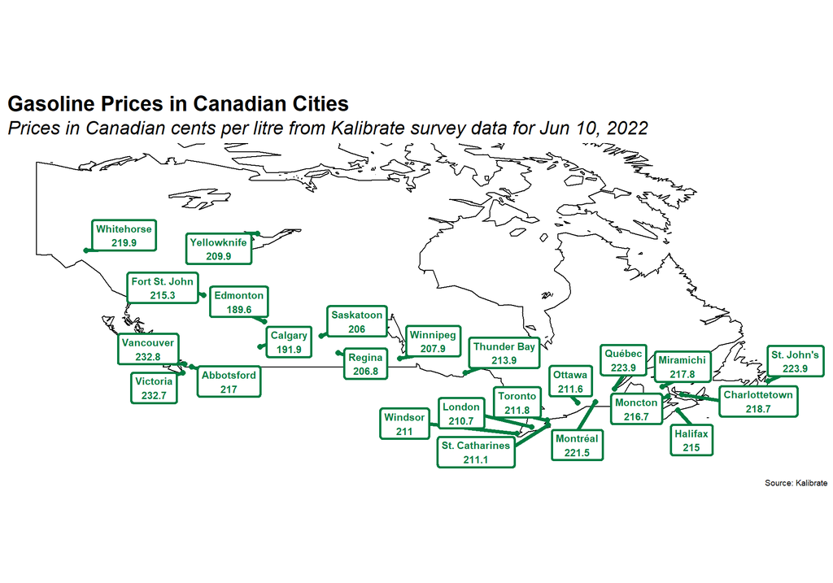

### Historic Gasoline Prices

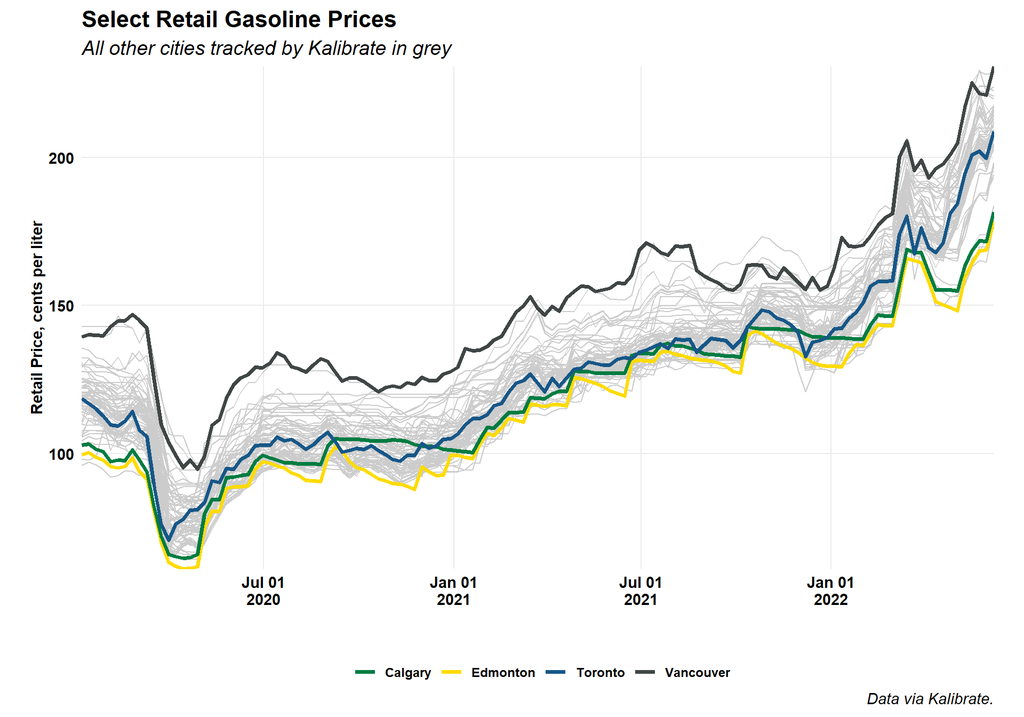

### Historic Diesel Prices

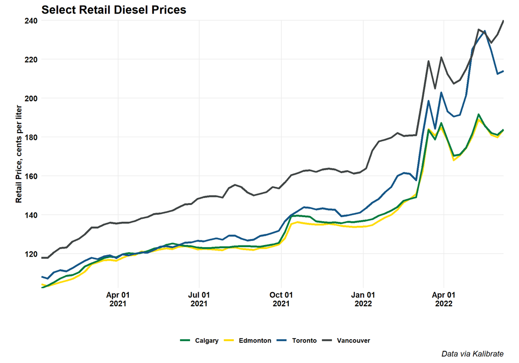

## Canadian Refinery Runs

### Canadian Refinery Runs

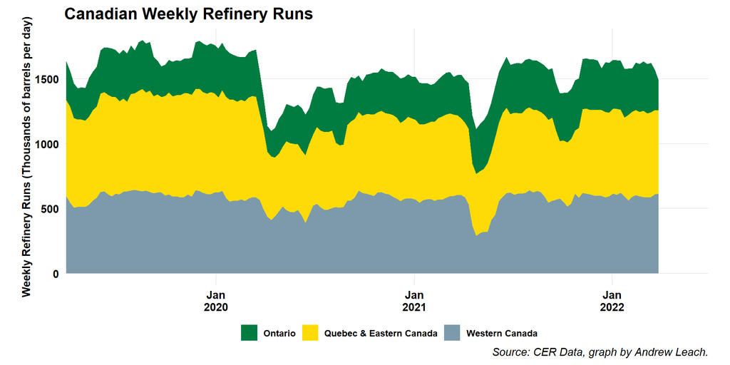

### Western Canada Refinery Runs

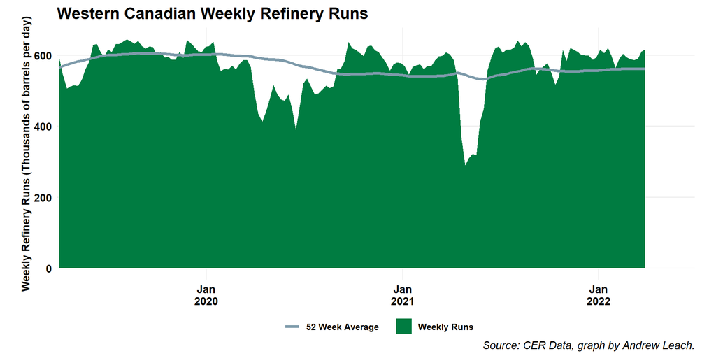

# Natural Gas

## Natural Gas Market Summary

### Feature Gas

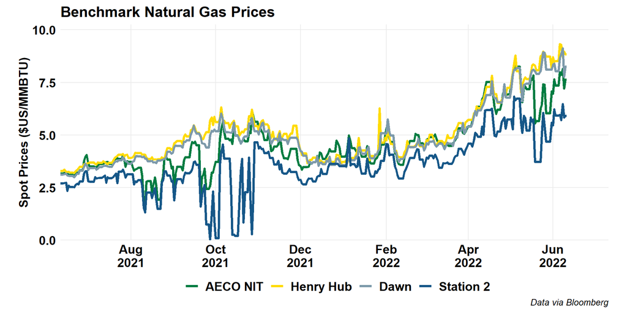

### Global Gas

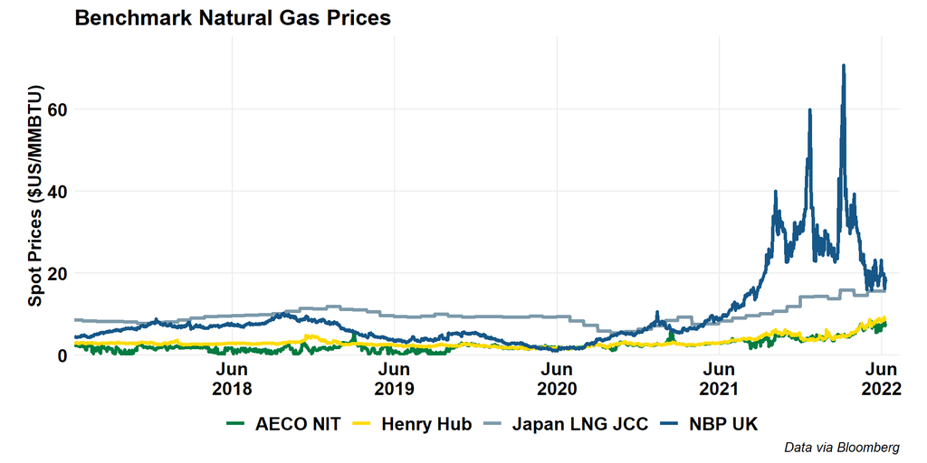

### North American Gas Hubs

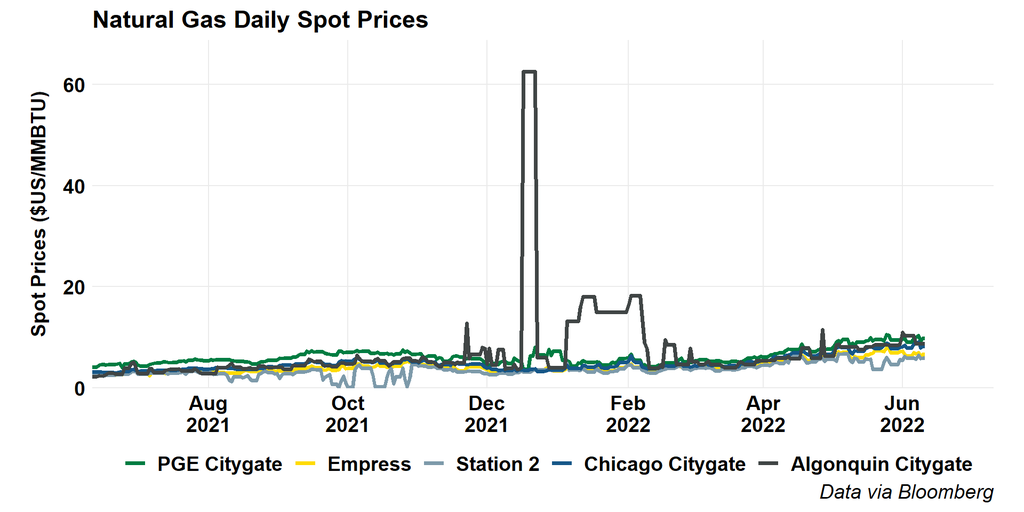

## Forward Prices

### Henry Hub

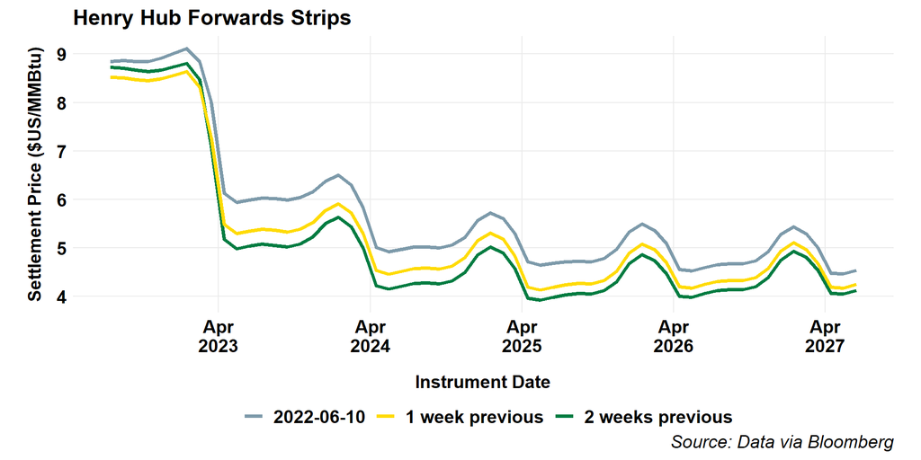

### Alberta (NIT) ($CAD)

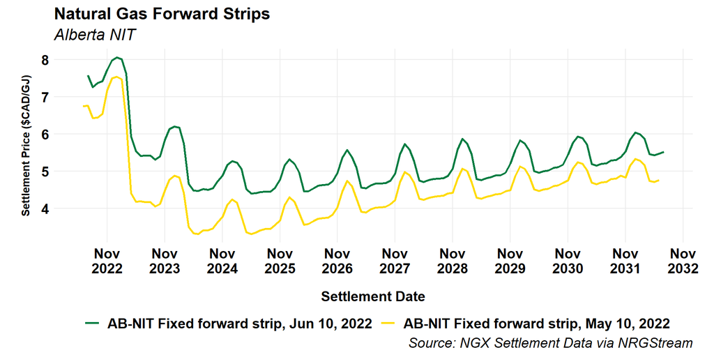

### Alberta (NIT)

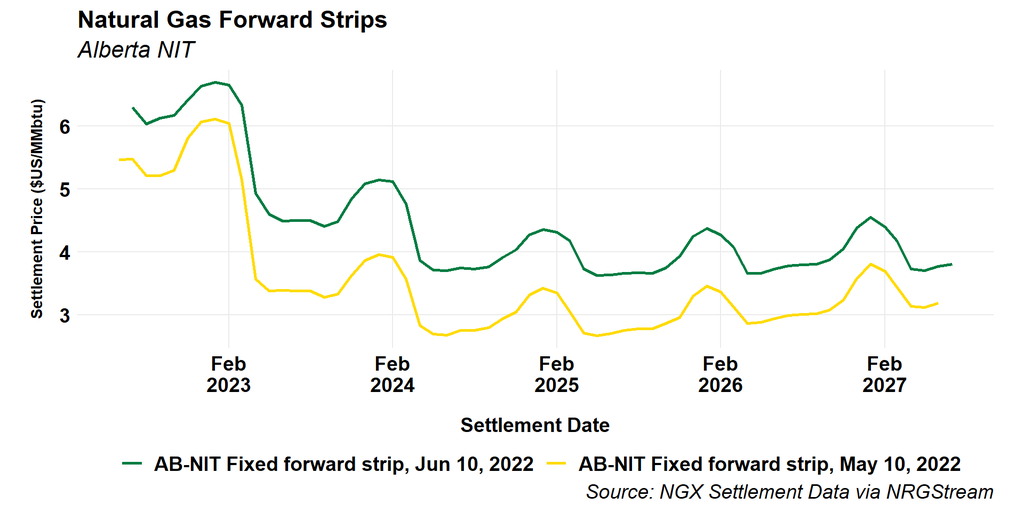